# O “andar do bêbado”

CE-312 - Estatística Computacional

Autor

Vinicius de Lima Santana - GRR20233890

# 1 Introdução

## 1.1 Descrição do Problema

O problema do “Andar do Bêbado” é um exemplo clássico de **trajetória aleatória** (*random walk*), aqui proposto por Dachs (1988) em um contexto urbano. A situação é a seguinte: um indivíduo parte do cruzamento na coordenada $(0, 0)$ de uma malha de ruas com quadras quadradas de lado $1$ e tenta chegar à sua casa, localizada no ponto $(3, 4)$. A cada esquina, ele escolhe aleatoriamente uma das quatro direções cardeais segundo as probabilidades descritas na Tabela 1.

Tabela 1: Probabilidades de deslocamento em cada direção.

| Direção | Vetor de deslocamento | Probabilidade |
| --- | --- | --- |
| Leste | $(+1,\; 0)$ | $0{,}35$ |
| Norte | $(0,\; +1)$ | $0{,}45$ |
| Sul | $(0,\; -1)$ | $0{,}10$ |
| Oeste | $(-1,\; 0)$ | $0{,}10$ |

Além do movimento propriamente dito, o modelo incorpora dois componentes de tempo:

- **Tempo de deslocamento:** cada quadra percorrida consome $5$ minutos.
- **Tempo de decisão:** com probabilidade $0{,}30$, ao chegar a uma esquina, o indivíduo demora $1$ minuto adicional antes de escolher a próxima direção.

O processo termina em uma de duas situações: (i) o indivíduo alcança o destino $(3, 4)$, ou (ii) o tempo total acumulado atinge ou ultrapassa o limite máximo estabelecido para a tentativa. O modelo é uma Cadeia de Markov em $\mathbb{Z}^2$: a decisão em cada esquina depende apenas da posição atual, não da trajetória anterior. Como $P(T \leq 60)$ não tem forma fechada, a estimativa é feita por Monte Carlo com $N = 100.000$ replicações independentes. A Figura 2 ilustra a malha urbana e as probabilidades de movimento.

## 1.2 Análise do Espaço de Soluções

### 1.2.1 Tempo mínimo possível de chegada

A distância de Manhattan entre origem e destino é $|3| + |4| = 7$ quadras, logo o caminho mais curto possível leva:

$$t_{\min} = 7 \times 5 = 35 \text{ minutos}$$

Esse valor exige $3$ passos para leste e $4$ para norte em sequência direta, sem nenhum atraso de decisão — evento possível mas de probabilidade muito baixa. Qualquer passo para sul ou oeste aumenta o total em pelo menos dois passos. Portanto, $35$ minutos é o **limite inferior absoluto** do tempo de chegada.

### 1.2.2 Estrutura dos caminhos possíveis

Seja uma trajetória qualquer de chegada ao destino composta por $n_L$, $n_N$, $n_S$ e $n_O$ passos nas direções leste, norte, sul e oeste, respectivamente. Para que o bêbado chegue exatamente em $(3, 4)$ partindo de $(0, 0)$, é necessário satisfazer o sistema:

$$\begin{cases} n_L - n_O = 3 \\ n_N - n_S = 4 \end{cases}$$

O número **total** de passos de um caminho de chegada é:

$$n = n_L + n_N + n_S + n_O = (n_O + 3) + (n_S + 4) + n_S + n_O = 7 + 2n_S + 2n_O$$

Como $n_S, n_O \geq 0$ e são inteiros, conclui-se que:

$$n \in \{7,\, 9,\, 11,\, 13,\, \ldots\}$$

Ou seja, **o número de passos de qualquer trajetória de chegada é sempre ímpar e pelo menos igual a 7**. Cada passo para sul ou oeste “desperdiçado” exige um passo compensatório extra, de modo que desvios do caminho mínimo aumentam o total de passos sempre de **dois em dois**.

### 1.2.3 Estrutura discreta dos tempos de chegada

Dado um caminho com $n = 7 + 2j$ passos ($j = 0, 1, 2, \ldots$), o tempo total acumulado é composto por:

- **Tempo de deslocamento:** $5n = 5(7 + 2j) = 35 + 10j$ minutos.
- **Tempo de decisão:** cada uma das $n$ esquinas visitadas gera um atraso de $1$ minuto com probabilidade $0{,}30$, independentemente. Se $d$ dessas esquinas causam atraso ($0 \leq d \leq n$), o custo adicional é $d$ minutos.

O tempo de chegada de uma trajetória com $j$ desvios (ou seja, $2j$ passos extras) e $d$ atrasos é portanto:

$$t = 35 + 10j + d, \quad j \in \{0, 1, 2, \ldots\},\quad d \in \{0, 1, \ldots, 7 + 2j\}$$

Isso implica que os tempos possíveis de chegada **não são arbitrários**: eles formam famílias de inteiros separadas por múltiplos de $10$, com sobreposição parcial entre famílias adjacentes quando $d$ é grande. A Tabela 2 exemplifica as primeiras famílias:

Tabela 2: Famílias de tempos de chegada por número de passos.

| Passos ($n$) | $j$ | Intervalo de $t$ possível |
| --- | --- | --- |
| 7 | 0 | $[35,\; 42]$ |
| 9 | 1 | $[45,\; 54]$ |
| 11 | 2 | $[55,\; 66]$ |
| 13 | 3 | $[65,\; 78]$ |

Note que entre $43$ e $44$ minutos **não há chegadas possíveis**: é um “vazio” estrutural entre a família $j=0$ e $j=1$. A partir de $j=2$ e $j=3$, as famílias começam a se sobrepor (ex.: $t = 65$ é atingível tanto com $j=2, d=10$ quanto com $j=3, d=0$). Essa estrutura **prediz a forma multimodal** da distribuição de tempos observada nas simulações da Seção 3.4 — os picos visíveis no histograma correspondem às modas de cada família. A Figura 1 exibe graficamente os tempos possíveis para as primeiras cinco famílias.

### 1.2.4 Probabilidade do caminho mínimo

O caminho mais curto ($j=0$, sem desvios) exige exatamente $3$ passos para leste e $4$ para norte, em qualquer ordem, sem nenhum passo para sul ou oeste. O número de sequências distintas com essa restrição é $\binom{7}{3} = 35$. A probabilidade de cada sequência específica de $3$ lestes e $4$ nortes (sem atrasos) é:

$$P(\text{sequência mínima sem atraso}) = 0{,}35^3 \times 0{,}45^4 \times 0{,}70^7$$

E a probabilidade de chegar pelo caminho mínimo em exatamente $t = 35$ minutos é:

$$P(t = 35) = \binom{7}{3} \times 0{,}35^3 \times 0{,}45^4 \times 0{,}70^7
= 35 \times 0{,}042875 \times 0{,}041006 \times 0{,}082354 \approx 0{,}005$$

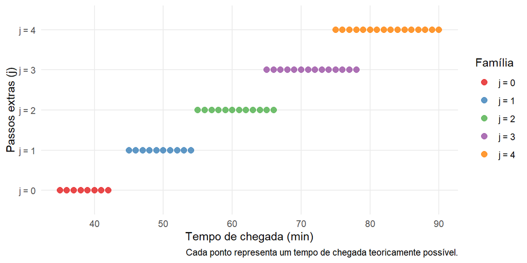

Figura 1: Famílias de tempos de chegada por número de passos (j). Cores distintas indicam famílias diferentes; a sobreposição entre j=2 e j=3 é visível a partir de t=65.

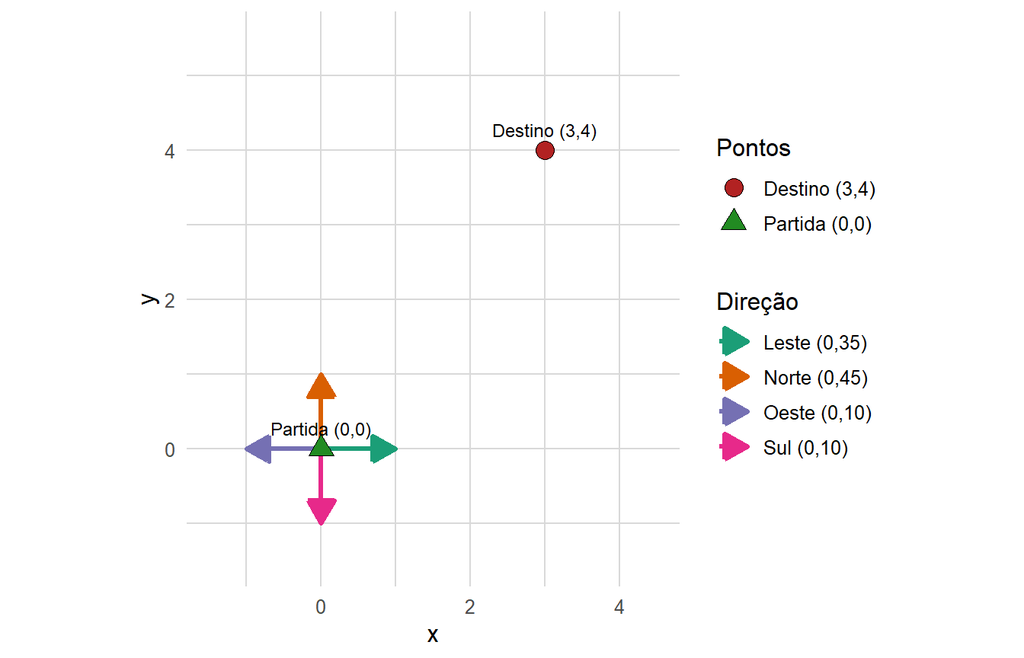

Figura 2: Malha urbana com ponto de partida (verde), destino (vermelho) e probabilidades de cada direção.

# 2 Simulação Interativa

Antes de rodar 100 mil tentativas, veja um bêbado andando de verdade: um passo de cada vez, com o tempo acumulando em tempo real. Quando a simulação terminar, o botão vermelho roda 100.000 tentativas instantaneamente e exibe o mapa de calor de posições visitadas.

#### 🚶 Simulação interativa — O Bêbado ao Vivo

[interactive chart not shown]

Posição

(0, 0)

Tempo

0 min

Passos

0

Clique em **Iniciar** para começar, ou no botão vermelho para o mapa de calor.

Simulação ao vivo

⏱ T. máximo 60 min

⚡ Velocidade 5

Probabilidades de direção

→ Direita 35% ↑ Cima 45% ↓ Baixo 10% ← Esquerda 10%

Total: 100%

Mapa de calor — 100.000 tentativas

Legenda

● O = Origem (0,0) ● D = Destino (3,4)  
● andando ● chegou ● tempo esgotado

# 3 Implementação e Análise

## 3.1 Função de Simulação

A função `simular_bebado()` centraliza a lógica do modelo. A chegada é verificada antes do critério de tempo para garantir o registro exato do instante de parada, e o armazenamento da trajetória (`guardar_traj = TRUE`) é desativado por padrão para otimização de memória.

**Código**

```r
# Parâmetros globais do problema
DESTINO       <- c(3, 4)
TEMPO_QUADRA  <- 5
TEMPO_DECISAO <- 1
P_SEM_ATRASO  <- 0.7
PROBS_DIR   <- c(leste = 0.35, norte = 0.45, sul = 0.10, oeste = 0.10)
DELTAS <- list(
  leste  = c( 1L,  0L),
  norte  = c( 0L,  1L),
  sul    = c( 0L, -1L),
  oeste  = c(-1L,  0L)
)
DIRS        <- names(DELTAS)

# Função principal
#
# Simula uma tentativa do bêbado.
#
# Argumentos:
#   tempo_max    : limite de tempo em minutos (critério de parada)
#   guardar_traj : se TRUE, armazena todas as coordenadas visitadas
#
# Retorna uma lista com:
#   $chegou  : logical — TRUE se o destino foi alcançado
#   $tempo   : numeric — tempo acumulado ao encerrar a tentativa
#   $traj    : matriz Nx2 com as coordenadas (apenas se guardar_traj = TRUE)

simular_bebado <- function(tempo_max, guardar_traj = FALSE) {
  pos   <- c(0L, 0L)
  tempo <- 0

  # pré-aloca trajetória só quando necessário
  if (guardar_traj) {
    traj        <- matrix(0L, nrow = 500L, ncol = 2L)
    traj[1L, ]  <- pos
    passo_traj  <- 1L
  }

  repeat {
    # atraso de decisão (30% das esquinas)
    if (runif(1L) > P_SEM_ATRASO) tempo <- tempo + TEMPO_DECISAO

    # escolhe direção e avança
    dir <- sample(DIRS, 1L, prob = PROBS_DIR[DIRS])
    pos <- pos + DELTAS[[dir]]
    tempo <- tempo + TEMPO_QUADRA

    # salva posição se modo trajetória
    if (guardar_traj) {
      passo_traj         <- passo_traj + 1L
      traj[passo_traj, ] <- pos
    }

    # verifica chegada antes do limite de tempo
    if (pos[1L] == DESTINO[1L] && pos[2L] == DESTINO[2L]) {
      return(list(
        chegou = TRUE,
        tempo  = tempo,
        traj   = if (guardar_traj) traj[seq_len(passo_traj), , drop = FALSE] else NULL
      ))
    }

    # critério de parada por tempo
    if (tempo >= tempo_max) {
      return(list(
        chegou = FALSE,
        tempo  = tempo,
        traj   = if (guardar_traj) traj[seq_len(passo_traj), , drop = FALSE] else NULL
      ))
    }
  }
}
```

### 3.1.1 Execução das $N = 100.000$ simulações

As simulações principais são executadas uma única vez e armazenadas em `resultados`. Todas as seções seguintes consomem esse mesmo objeto, sem re-simular.

**Código**

```r
N         <- 100000L
TEMPO_MAX <- 180

resultados <- replicate(N, simular_bebado(TEMPO_MAX), simplify = FALSE)

chegou <- vapply(resultados, `[[`, logical(1L),  "chegou")
tempo  <- vapply(resultados, `[[`, numeric(1L),  "tempo")
```

### 3.1.2 Verificação de Sanidade

Antes de qualquer análise, verificamos se a simulação se comporta como esperado com base na teoria da Seção 1.2.

**Código**

```r
tempos_chegada <- tempo[chegou]

# P(t = 35) marginal: chegadas com t = 35 sobre TODAS as N simulações
p35_sim <- mean(chegou & tempo == 35)
p35_teo <- choose(7, 3) * 0.35^3 * 0.45^4 * 0.70^7

# Criar data frame com os resultados
sanity_df <- data.frame(
  Verificação = c(
    "Tempo mínimo de chegada",
    "Chegadas com $t < 35$ min",
    "Probabilidade $t = 35$ min",
    "Taxa de chegada ($\\leq 60$ min)"
  ),
  Observado = c(
    paste0(min(tempos_chegada), " min"),
    paste0(sum(tempos_chegada < 35), " casos"),
    sprintf("%.4f", p35_sim),
    sprintf("%.1f\\%%", 100 * mean(chegou & tempo <= 60))  # filtro explícito: ≤ 60
  ),
  Esperado = c(
    "$\\geq 35$ min",
    "0 casos",
    sprintf("%.4f", p35_teo),
    "---"
  ),
  Status = c(
    ifelse(min(tempos_chegada) >= 35, "$\\checkmark$", "$\\times$"),
    ifelse(sum(tempos_chegada < 35) == 0, "$\\checkmark$", "$\\times$"),
    ifelse(abs(p35_sim - p35_teo) < 0.001, "$\\checkmark$", "$\\times$"),
    "---"
  )
)

knitr::kable(
  sanity_df,
  align = c("l", "c", "c", "c"),
  caption = "Verificação de sanidade dos resultados simulados.",
  col.names = c("Verificação", "Observado", "Esperado", "Status"),
  escape = FALSE
)
```

Verificação de sanidade dos resultados simulados.

| Verificação | Observado | Esperado | Status |
| --- | --- | --- | --- |
| Tempo mínimo de chegada | 35 min | $\geq 35$ min | $\checkmark$ |
| Chegadas com $t < 35$ min | 0 casos | 0 casos | $\checkmark$ |
| Probabilidade $t = 35$ min | 0.0046 | 0.0051 | $\checkmark$ |
| Taxa de chegada ($\leq 60$ min) | 18.2% | — | — |

## 3.2 Estimativa de $P(\text{chegada} \leq 60 \text{ min})$

O primeiro objetivo é estimar a probabilidade de o bêbado chegar em casa em até $60$ minutos, acompanhada de uma medida de incerteza. O estimador pontual é a proporção amostral $\hat{p} = k/N$, onde $k$ é o número de chegadas observadas nas $N$ simulações.

### 3.2.1 Estimativa e intervalos de confiança

**Código**

```r
k     <- sum(chegou & tempo <= 60)
p_hat <- mean(chegou & tempo <= 60)
ep    <- sqrt(p_hat * (1 - p_hat) / N)
```

Das $N = 100.000$ simulações, $k = 18240$ chegaram em até $60$ minutos, resultando em $\hat{p} = 0.18240$ com erro padrão $\text{EP} = 0.001221$.

O **intervalo de Wilson** — preferível ao intervalo normal clássico por ter cobertura mais próxima do nível nominal para qualquer $\hat{p}$ — é obtido invertendo o teste de score de proporção:

$$\text{IC}_{95\%}^{\text{Wilson}} = \frac{\hat{p} + \frac{z^2}{2N} \pm
z\sqrt{\frac{\hat{p}(1-\hat{p})}{N} + \frac{z^2}{4N^2}}}{1 + \frac{z^2}{N}}$$

**Código**

```r
wilson_ic <- function(p, n, conf = 0.95) {
  z      <- qnorm(1 - (1 - conf) / 2)
  denom  <- 1 + z^2 / n
  centro <- (p + z^2 / (2 * n)) / denom
  margem <- (z * sqrt(p * (1 - p) / n + z^2 / (4 * n^2))) / denom
  c(inf = centro - margem, sup = centro + margem)
}
ic_wilson <- wilson_ic(p_hat, N)
```

O **Bootstrap não-paramétrico** reamostra os $N$ resultados binários com reposição $B = 10.000$ vezes e calcula o IC pelos percentis $2{,}5\%$ e $97{,}5\%$:

**Código**

```r
B        <- 10000L
chegou_60 <- chegou & tempo <= 60
p_boot   <- replicate(B, mean(sample(chegou_60, N, replace = TRUE)))
ic_boot  <- quantile(p_boot, c(0.025, 0.975))
ep_boot  <- sd(p_boot)
```

Comparação dos intervalos de confiança de 95% para $\hat{p}$.

| Método | Limite inferior | Limite superior | Amplitude | EP |
| --- | --- | --- | --- | --- |
| Wilson (95%) | 0.18002 | 0.18481 | 0.00479 | 0.00122 |
| Bootstrap percentil (95%) | 0.17999 | 0.18476 | 0.00477 | 0.00123 |

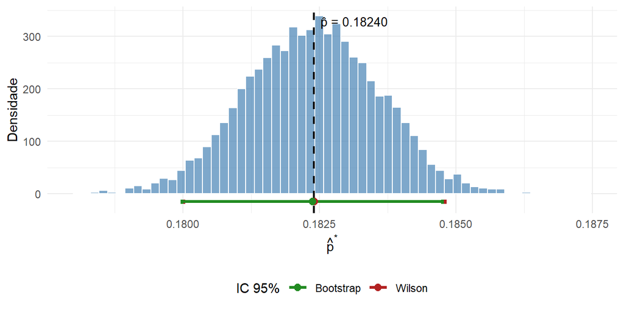

Figura 3: Distribuição bootstrap de $\hat{p}^*$ com intervalos de confiança sobrepostos. A linha tracejada indica a estimativa pontual.

Com $N = 100.000$, Wilson e Bootstrap convergem para limites praticamente idênticos — a diferença de amplitude fica na quarta casa decimal.

## 3.3 Distribuição do Número de Chegadas em 100 Tentativas

O segundo objetivo é obter a distribuição do **número de chegadas** quando se realizam $m = 100$ tentativas independentes. Cada tentativa é um ensaio de Bernoulli com probabilidade de sucesso $p = P(\text{chegada} \leq 60 \text{ min})$, estimada na seção anterior. Como as tentativas são independentes entre si, o número de chegadas $K$ em $m = 100$ tentativas segue uma distribuição **Binomial**:

$$K \sim \text{Binomial}(m = 100,\; p)$$

A simulação permite verificar empiricamente essa afirmação — e o ajuste entre a distribuição simulada e a Binomial teórica serve como outro *sanity check* do modelo.

### 3.3.1 Simulação das 100 tentativas

Reutilizamos os $N = 100.000$ resultados já simulados: basta reorganizá-los em $N/m = 1.000$ grupos de $m = 100$ tentativas cada e contar os sucessos em cada grupo.

**Código**

```r
m         <- 100L                      # tentativas por grupo
n_grupos  <- N %/% m                  # número de grupos = 1.000

# reorganiza o vetor 'chegou' em matriz (m linhas × n_grupos colunas)
# e soma cada coluna → número de chegadas por grupo
chegadas_100 <- colSums(matrix(chegou & tempo <= 60, nrow = m))

var_obs <- var(chegadas_100)
var_teo <- m * p_hat * (1 - p_hat)

dist_100_tbl <- data.frame(
  Estatística = c(
    "Número de grupos",
    "Tentativas por grupo",
    "Média observada",
    "Média teórica ($m \\cdot \\hat{p}$)",
    "Variância observada",
    "Variância teórica ($m \\cdot \\hat{p} \\cdot (1-\\hat{p})$)",
    "Desvio padrão observado",
    "Erro padrão da média"
  ),
  Valor = c(
    as.character(n_grupos),
    as.character(m),
    sprintf("%.3f", mean(chegadas_100)),
    sprintf("%.3f", m * p_hat),
    sprintf("%.3f", var_obs),
    sprintf("%.3f", var_teo),
    sprintf("%.3f", sd(chegadas_100)),
    sprintf("%.3f", sd(chegadas_100) / sqrt(n_grupos))
  )
)

knitr::kable(
  dist_100_tbl,
  align = c("l", "r"),
  caption = "Estatísticas da distribuição do número de chegadas em 100 tentativas.",
  col.names = c("Estatística", "Valor")
)
```

Estatísticas da distribuição do número de chegadas em 100 tentativas.

| Estatística | Valor |
| --- | --- |
| Número de grupos | 1000 |
| Tentativas por grupo | 100 |
| Média observada | 18.240 |
| Média teórica ($m \cdot \hat{p}$) | 18.240 |
| Variância observada | 14.443 |
| Variância teórica ($m \cdot \hat{p} \cdot (1-\hat{p})$) | 14.913 |
| Desvio padrão observado | 3.800 |
| Erro padrão da média | 0.120 |

A variância teórica da $\text{Binomial}(m, p)$ é $m \cdot p \cdot (1-p)$. A comparação com a variância observada é mais um *sanity check*: valores próximos indicam que o modelo Binomial é adequado para descrever a distribuição empírica.

### 3.3.2 Estatísticas descritivas

Estatísticas descritivas da distribuição simulada do número de chegadas em $m = 100$ tentativas versus referência Binomial$(100,\, \hat{p})$.

| Estatística | Observado | Teórico |
| --- | --- | --- |
| Mínimo | 6.00 | 0.000 |
| P2,5% | 11.00 | 11.000 |
| Q1 (25%) | 16.00 | 16.000 |
| Mediana | 18.00 | 18.000 |
| Q3 (75%) | 21.00 | 21.000 |
| P97,5% | 26.00 | 26.000 |
| Máximo | 31.00 | 100.000 |
| Média | 18.24 | 18.240 |
| DP | 3.80 | 3.862 |

### 3.3.3 Ajuste à Binomial

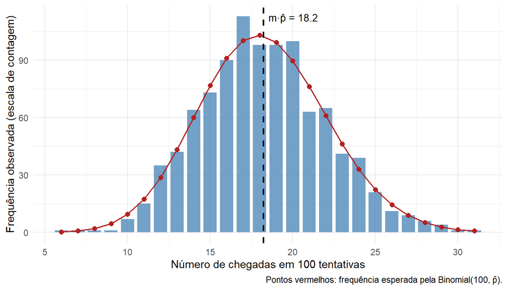

Figura 4: Distribuição simulada do número de chegadas em 100 tentativas (barras) versus probabilidades da Binomial$(100, \hat{p})$ teórica (pontos vermelhos). A linha tracejada indica a média teórica $m \cdot \hat{p}$.

### 3.3.4 Teste de aderência qui-quadrado

**Código**

```r
k_full       <- 0:m
obs_full     <- integer(m + 1L)
names(obs_full) <- k_full

obs_tab <- table(chegadas_100)
# indexação por posição: k=0 → índice 1, k=j → índice j+1
obs_full[as.integer(names(obs_tab)) + 1L] <- as.integer(obs_tab)

esp_full <- dbinom(k_full, size = m, prob = p_hat) * n_grupos

idx_inf <- min(which(cumsum(esp_full) >= 5))
idx_sup <- length(esp_full) - min(which(rev(cumsum(rev(esp_full))) >= 5)) + 1L

obs_freq_g <- c(
  sum(obs_full[seq_len(idx_inf)]),
  obs_full[(idx_inf + 1L):(idx_sup - 1L)],
  sum(obs_full[idx_sup:length(obs_full)])
)
esp_freq_g <- c(
  sum(esp_full[seq_len(idx_inf)]),
  esp_full[(idx_inf + 1L):(idx_sup - 1L)],
  sum(esp_full[idx_sup:length(esp_full)])
)
chi2_stat <- sum((obs_freq_g - esp_freq_g)^2 / esp_freq_g)
# gl = nº de classes - 1 (restrição de soma) - 1 (p estimado das 100k simulações)
# Tratar p_hat como parâmetro estimado é a opção conservadora; como ele vem de
# uma amostra independente (não dos 1000 grupos), gl = k-1 seria igualmente defensável
chi2_gl   <- length(obs_freq_g) - 2L
chi2_pval <- pchisq(chi2_stat, df = chi2_gl, lower.tail = FALSE)
```

Resultado do teste de aderência qui-quadrado para a distribuição Binomial(100, $\hat{p}$).

[output not shown]

O ajuste entre a distribuição simulada e a $\text{Binomial}(100, \hat{p})$ confirma que as tentativas são efetivamente independentes e identicamente distribuídas no modelo — propriedades que decorrem diretamente da estrutura de simulação adotada na Seção 3.1.

## 3.4 Distribuição dos Tempos de Chegada

A distribuição de $T$ é analisada condicionalmente a $T \leq 60$ min — tempos registrados em tentativas que expiraram não representam chegadas e não entram na distribuição.

### 3.4.1 Estrutura discreta confirmada

A Seção 1.2 derivou que os tempos possíveis de chegada pertencem ao conjunto $\{35 + 10j + d : j \geq 0,\; 0 \leq d \leq 7 + 2j\}$. Verificamos isso diretamente:

Primeiros 15 tempos de chegada únicos observados.

| Posição | Tempo (min) |
| --- | --- |
| 1 | 35 |
| 2 | 36 |
| 3 | 37 |
| 4 | 38 |
| 5 | 39 |
| 6 | 40 |
| 7 | 41 |
| 8 | 42 |
| 9 | 45 |
| 10 | 46 |
| 11 | 47 |
| 12 | 48 |
| 13 | 49 |
| 14 | 50 |
| 15 | 51 |

Estrutura da distribuição dos tempos de chegada.

| Característica | Valor |
| --- | --- |
| Total de valores distintos | 24 |
| Tempo mínimo | 35 min |
| Tempo máximo | 60 min |
| Amplitude total | 25 min |
| Tempos impossíveis ($43 \leq t \leq 44$) | 0 observados (esperado: 0) |

### 3.4.2 Estatísticas descritivas dos tempos de chegada

Estatísticas descritivas da distribuição dos tempos de chegada (tentativas bem-sucedidas).

| Estatística | Valor |
| --- | --- |
| Mínimo | 35.00 |
| P2,5% | 35.00 |
| Q1 (25%) | 38.00 |
| Mediana | 47.00 |
| Média | 47.07 |
| Q3 (75%) | 56.00 |
| P97,5% | 60.00 |
| Máximo | 60.00 |
| DP | 8.29 |

### 3.4.3 PDF empírica — frequência relativa por tempo

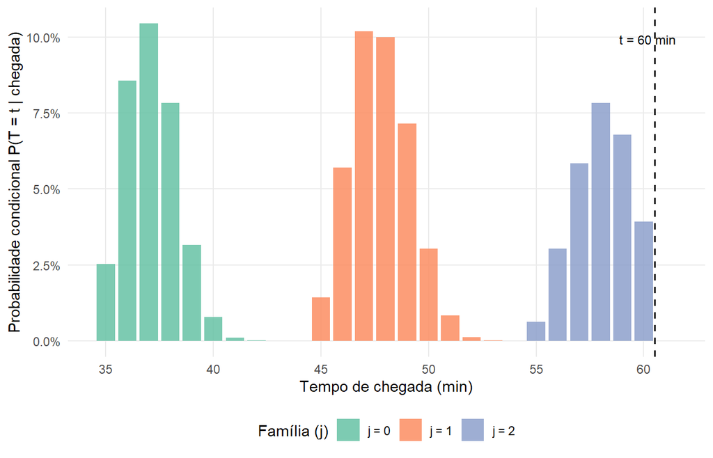

Figura 5: Distribuição de probabilidades dos tempos de chegada (tentativas bem-sucedidas). As famílias de tempo derivadas na Seção 1.2 produzem os grupos de barras visíveis, separados pelos vazios estruturais. A linha tracejada vertical marca o limite de 60 minutos.

### 3.4.4 CDF empírica dos tempos de chegada

A função de distribuição acumulada (CDF) responde diretamente à pergunta central do Item 1 — e também ao Item 4: dado qualquer limite de tempo $t^*$, qual a probabilidade de chegada?

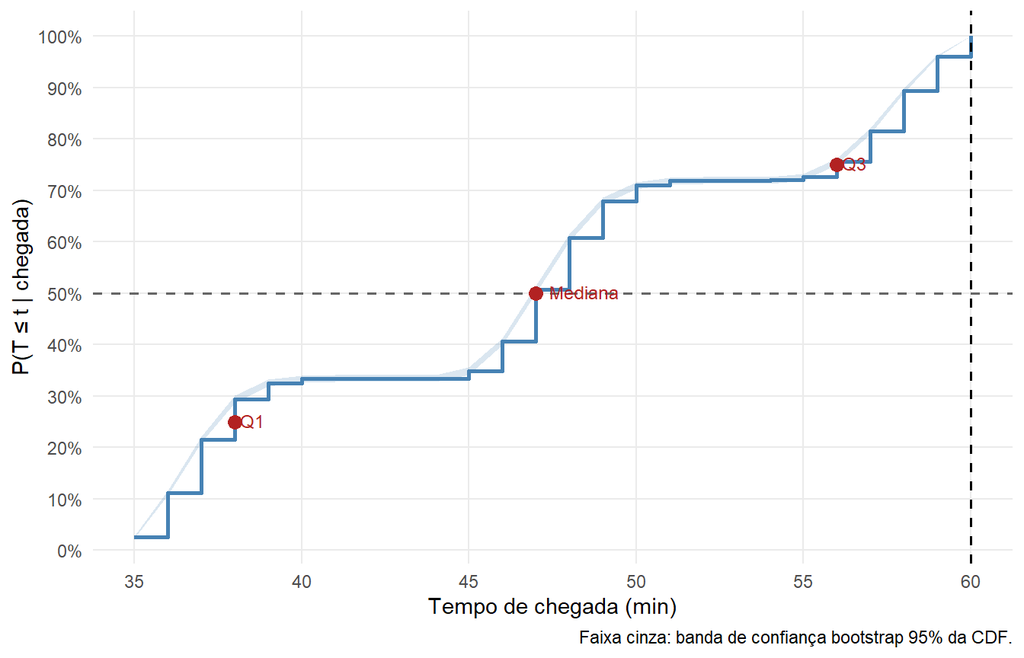

Figura 6: CDF empírica dos tempos de chegada (escada azul) com banda de confiança bootstrap de 95% (faixa azul clara). A linha tracejada horizontal marca $p = 0{,}50$ e a vertical marca $t = 60$ min. Os pontos vermelhos indicam os quantis $Q_1$, mediana e $Q_3$.

### 3.4.5 Tempo Médio de Chegada com IC Bootstrap

**Código**

```r
# IC bootstrap para a média dos tempos de chegada
B_med    <- 5000L
med_boot <- replicate(B_med,
              mean(sample(t_cheg, length(t_cheg), replace = TRUE)))

ic_med <- quantile(med_boot, c(0.025, 0.975))

media_tbl <- data.frame(
  Métrica = c(
    "Média",
    "Mediana",
    "Desvio padrão",
    "IC 95\\% inferior (Bootstrap)",
    "IC 95\\% superior (Bootstrap)",
    "Q1 (25\\%)",
    "Q3 (75\\%)",
    "Mínimo",
    "Máximo"
  ),
  Valor = c(
    sprintf("%.2f min", mean(t_cheg)),
    sprintf("%.0f min", median(t_cheg)),
    sprintf("%.2f min", sd(t_cheg)),
    sprintf("%.2f min", ic_med[1]),
    sprintf("%.2f min", ic_med[2]),
    sprintf("%.0f min", quantile(t_cheg, 0.25)),
    sprintf("%.0f min", quantile(t_cheg, 0.75)),
    sprintf("%.0f min", min(t_cheg)),
    sprintf("%.0f min", max(t_cheg))
  ),
  stringsAsFactors = FALSE
)

knitr::kable(
  media_tbl,
  align = c("l", "r"),
  caption = "Estatísticas descritivas dos tempos de chegada com IC Bootstrap 95\\%.",
  col.names = c("Métrica", "Valor"),
  escape = FALSE
)
```

Estatísticas descritivas dos tempos de chegada com IC Bootstrap 95%.

| Métrica | Valor |
| --- | --- |
| Média | 47.07 min |
| Mediana | 47 min |
| Desvio padrão | 8.29 min |
| IC 95% inferior (Bootstrap) | 46.95 min |
| IC 95% superior (Bootstrap) | 47.19 min |
| Q1 (25%) | 38 min |
| Q3 (75%) | 56 min |
| Mínimo | 35 min |
| Máximo | 60 min |

A distribuição dos tempos de chegada apresenta média e mediana praticamente coincidentes ($\bar{t} \approx \text{mediana} \approx 47.1$ min), indicando simetria aproximada **dentro da janela de observação**. Esse comportamento é consequência direta do truncamento em $t = 60$ min: ao restringir a análise às chegadas com $T \leq 60$, eliminamos a cauda direita gerada pelos caminhos mais longos ($j \geq 2$ com muitos atrasos), tornando a distribuição aproximadamente simétrica em torno do centro da família $j = 1$.

> **Nota sobre truncamento:** os 100000 cenários simulados utilizam `TEMPO_MAX = 180` min como horizonte de simulação (Seção 3.1), mas a análise desta seção é restrita às chegadas com $T \leq 60$ min via filtro `tempo[chegou & tempo <= 60]`. Portanto, a distribuição de $T$ analisada aqui é **condicional** a $T \leq 60$ min; chegadas em $t > 60$ min (família $j = 2$ com $d > 5$, e $j \geq 3$) não integram esta distribuição. A “longa cauda à direita” da distribuição **incondicional** de $T$ é visível na curva $p(t^*)$ da Seção 3.5, que utiliza os dados completos do horizonte de 180 min.

O Bootstrap fornece um intervalo de confiança para a média sem suposições paramétricas sobre a distribuição de $T$, com amplitude estreita — reflexo da grande quantidade de chegadas observadas.

## 3.5 Curva de Chegada por Limite de Tempo

O quarto objetivo é investigar como a probabilidade de chegada $p(t^*) = P(T \leq t^*)$ varia em função do tempo máximo permitido $t^*$, partindo do menor valor possível $t^* = 35$ minutos.

A estratégia adotada é eficiente: em vez de re-simular $N$ tentativas para cada valor de $t^*$, **reutilizamos os tempos de chegada já simulados**. Para cada $t^*$, basta contar quantas chegadas tiveram $\text{tempo} \leq t^*$ e dividir por $N$. Isso equivale a avaliar a CDF da distribuição marginal de $T$ (incluindo as não-chegadas como $T = +\infty$) em cada ponto da grade.

**Código**

```r
# grade de t* de 35 a 3 horas (limite superior generoso para ver convergência)
t_grid <- 35:180

# p(t*) = proporção de simulações que chegaram em tempo ≤ t*
# (inclui não-chegadas, cujo tempo é "infinito" → nunca contam)
p_grid <- sapply(t_grid, function(t_star) mean(chegou & tempo <= t_star))

# IC de Wilson para cada ponto da grade
ic_grid <- t(sapply(p_grid, wilson_ic, n = N))   # reutiliza wilson_ic() da seção 3.2

curva_df <- data.frame(
  t    = t_grid,
  p    = p_grid,
  inf  = ic_grid[, "inf"],
  sup  = ic_grid[, "sup"]
)

# limite assintótico: probabilidade de chegada com tempo ilimitado
# estimado como p(t* = max observado entre chegadas)
p_assintotico <- mean(chegou)   # = p̂ da seção 3.2

# Marcos de tempo relevantes
marcos <- c(35, 40, 45, 50, 55, 60, 70, 80, 90, 120, 150, 180)

curva_marcos <- data.frame(
  `Tempo-limite $t^*$ (min)` = marcos,
  `$P(T \\leq t^*)$` = sprintf("%.5f", curva_df$p[curva_df$t %in% marcos]),
  `IC 95\\% (inferior)` = sprintf("%.5f", curva_df$inf[curva_df$t %in% marcos]),
  `IC 95\\% (superior)` = sprintf("%.5f", curva_df$sup[curva_df$t %in% marcos]),
  check.names = FALSE
)

# Adicionar linha do limite assintótico
curva_marcos <- rbind(
  curva_marcos,
  data.frame(
    `Tempo-limite $t^*$ (min)` = "$\\infty$",
    `$P(T \\leq t^*)$` = sprintf("%.5f", p_assintotico),
    `IC 95\\% (inferior)` = sprintf("%.5f", wilson_ic(p_assintotico, N)["inf"]),
    `IC 95\\% (superior)` = sprintf("%.5f", wilson_ic(p_assintotico, N)["sup"]),
    check.names = FALSE
  )
)

knitr::kable(
  curva_marcos,
  align = c("c", "c", "c", "c"),
  caption = "Probabilidade estimada de chegada $P(T \\leq t^*)$ para tempos-limite selecionados, com IC de Wilson (95\\%). A última linha mostra o limite assintótico $p(\\infty)$.",
  col.names = c("Tempo-limite $t^*$ (min)", "$P(T \\leq t^*)$", "IC 95\\% inferior", "IC 95\\% superior"),
  escape = FALSE
)
```

Probabilidade estimada de chegada $P(T \leq t^*)$ para tempos-limite selecionados, com IC de Wilson (95%). A última linha mostra o limite assintótico $p(\infty)$.

| Tempo-limite $t^*$ (min) | $P(T \leq t^*)$ | IC 95% inferior | IC 95% superior |
| --- | --- | --- | --- |
| 35 | 0.00461 | 0.00421 | 0.00505 |
| 40 | 0.06077 | 0.05931 | 0.06227 |
| 45 | 0.06361 | 0.06211 | 0.06514 |
| 50 | 0.12943 | 0.12736 | 0.13152 |
| 55 | 0.13238 | 0.13029 | 0.13449 |
| 60 | 0.18240 | 0.18002 | 0.18481 |
| 70 | 0.21987 | 0.21731 | 0.22245 |
| 80 | 0.24494 | 0.24228 | 0.24762 |
| 90 | 0.26236 | 0.25964 | 0.26510 |
| 120 | 0.28741 | 0.28461 | 0.29022 |
| 150 | 0.29465 | 0.29183 | 0.29748 |
| 180 | 0.29651 | 0.29369 | 0.29935 |
| $\infty$ | 0.29664 | 0.29382 | 0.29948 |

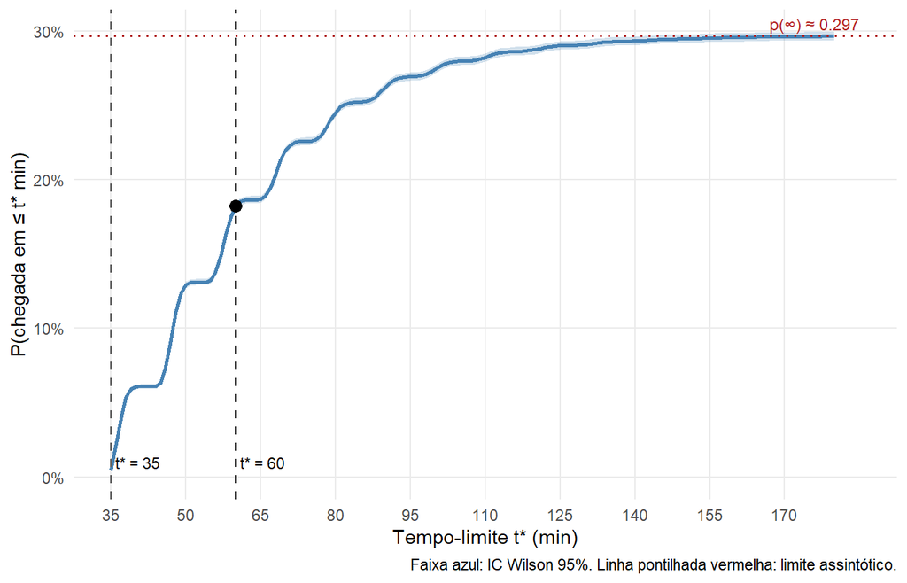

A região $35 \leq t^* \leq 90$ min concentra o comportamento mais rico: os saltos das famílias $j$ e os platôs dos vazios estruturais são claramente visíveis no zoom abaixo.

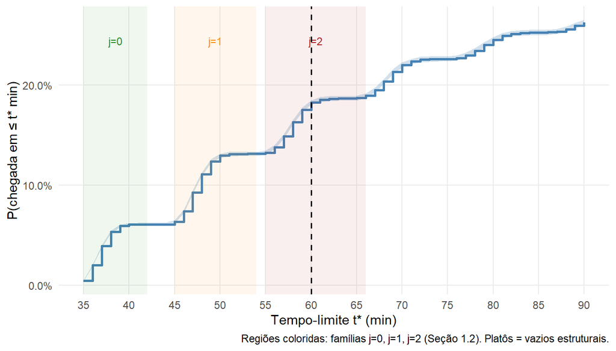

Figura 8: Zoom da curva $p(t^*)$ entre 35 e 90 minutos. Os platôs horizontais correspondem aos vazios estruturais entre famílias de caminhos (Seção 1.2). Os degraus mais acentuados indicam as regiões de maior concentração de tempos de chegada.

A curva $p(t^*)$ apresenta três fases distintas:

**Fase 1 — Crescimento em degraus ($35 \leq t^* \lesssim 65$ min):** as famílias $j = 0$, $j = 1$ e $j = 2$ contribuem com blocos de probabilidade concentrados, separados pelos platôs dos vazios estruturais (Seção 1.2). O crescimento é irregular e descontínuo nessa região, com os maiores saltos ocorrendo nos centros de cada família.

**Fase 2 — Crescimento suave ($65 \lesssim t^* \lesssim 120$ min):** as famílias $j \geq 3$ passam a contribuir, com probabilidades cada vez menores. O viés acentuado para leste e norte ($P(L) + P(N) = 0{,}80$) torna muito improvável que um caminho acumule três ou mais pares de passos desperdiçados, de modo que os incrementos nessa fase são pequenos e a curva começa a se achatar progressivamente.

**Fase 3 — Convergência assintótica ($t^* \gtrsim 120$ min):** a curva se aproxima do limite $p(\infty) < 1$ de forma assintótica. O limite é estritamente menor que 1 porque existe probabilidade positiva (embora muito pequena) de o bêbado nunca chegar — por exemplo, sequências longas de passos para oeste e sul. Nas $N = 100.000$ simulações, as chegadas além de $t^* \approx 150$ min tornam-se raríssimas, e a curva estabiliza empiricamente antes do horizonte de $180$ min.

Taxa de convergência da probabilidade de chegada em direção ao limite assintótico $p(\infty)$.

| Tempo-limite $t^*$ (min) | $P(T \leq t^*)$ | Fração de $p(\infty)$ | Prob. restante |
| --- | --- | --- | --- |
| 35 | 0.00461 | 1.55% | 98.45% |
| 45 | 0.06361 | 21.44% | 78.56% |
| 55 | 0.13238 | 44.63% | 55.37% |
| 60 | 0.18240 | 61.49% | 38.51% |
| 70 | 0.21987 | 74.12% | 25.88% |
| 90 | 0.26236 | 88.44% | 11.56% |
| 120 | 0.28741 | 96.89% | 3.11% |

# 4 Visualizações

## 4.1 Trajetórias Sobrepostas: Sucesso vs. Falha

**Código**

```r
# simula separadamente sucessos e falhas com trajetória gravada
# repete até obter n_cada de cada tipo
set.seed(777)
n_cada <- 20L   # 20 sucessos + 20 falhas

# "sucesso" e "falha" referem-se ao horizonte de simulação TEMPO_MAX = 180 min,
# independente do critério analítico de 60 min usado nas seções anteriores
trajs_suc <- vector("list", n_cada)
trajs_fal <- vector("list", n_cada)
i_s <- 0L; i_f <- 0L

while (i_s < n_cada || i_f < n_cada) {
  res <- simular_bebado(TEMPO_MAX, guardar_traj = TRUE)
  if (res$chegou && i_s < n_cada) {
    i_s <- i_s + 1L
    trajs_suc[[i_s]] <- data.frame(
      res$traj, id = i_s, tipo = "Sucesso"
    )
  } else if (!res$chegou && i_f < n_cada) {
    i_f <- i_f + 1L
    trajs_fal[[i_f]] <- data.frame(
      res$traj, id = i_f, tipo = "Falha"
    )
  }
}

# consolida em um único data frame
traj_df <- dplyr::bind_rows(c(trajs_suc, trajs_fal)) |>
  dplyr::rename(x = X1, y = X2) |>
  dplyr::group_by(id, tipo) |>
  dplyr::mutate(passo = dplyr::row_number()) |>
  dplyr::ungroup()
```

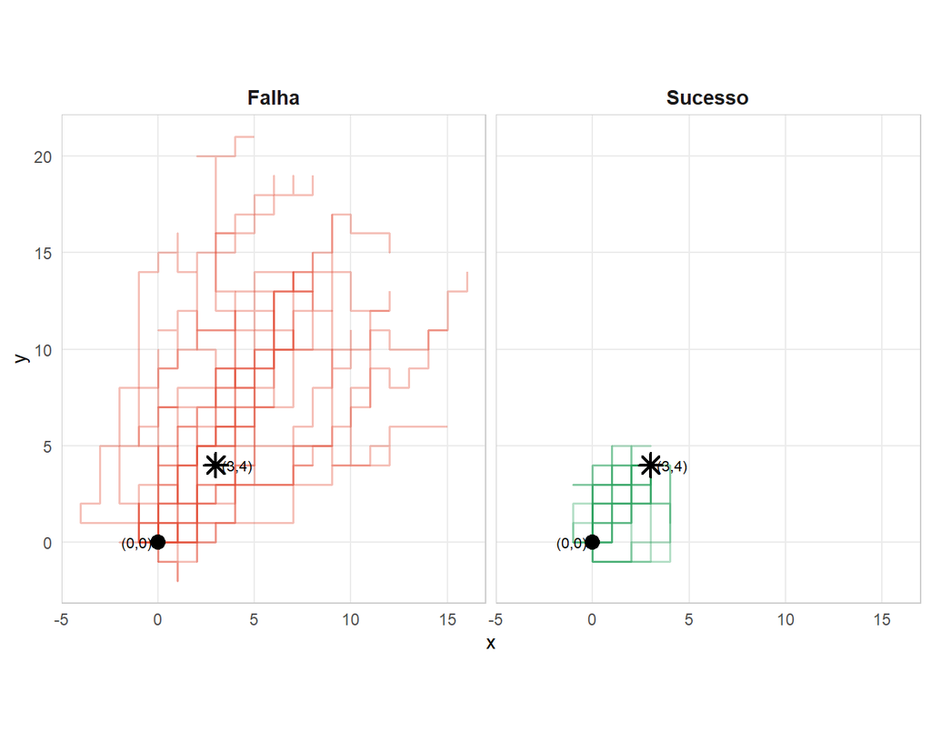

Figura 9: Vinte trajetórias de sucesso (verde, painel direito) e vinte de falha (vermelho, painel esquerdo). Cada linha representa uma tentativa independente. O ponto sólido grande indica a origem $(0,0)$ e o asterisco o destino $(3,4)$. O alpha baixo revela as sobreposições, regiões mais escuras são visitadas por múltiplas trajetórias.

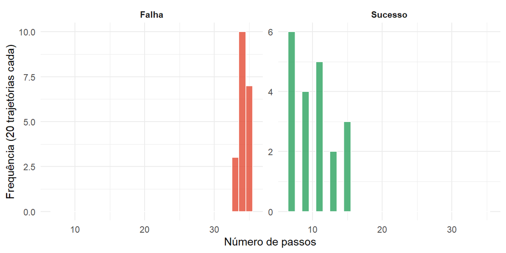

Figura 10: Distribuição do número de passos por trajetória, separado por desfecho. Trajetórias de falha tendem a ser mais longas pois continuam até o limite de tempo; trajetórias de sucesso concentram-se nos valores mínimos compatíveis com a chegada.

## 4.2 Mapa de Calor das Posições Visitadas

As 40 trajetórias da seção anterior são ilustrativas, mas insuficientes para estimar com precisão quais regiões da malha são mais frequentadas. Para isso, simulamos um número maior de trajetórias completas e contamos quantas vezes cada coordenada $(x, y)$ foi visitada — separando sucessos de falhas para revelar como os padrões de ocupação diferem entre os dois desfechos.

**Código**

```r
set.seed(777)
n_tipo  <- 1000L   # 1000 sucessos + 1000 falhas

# critério: chegou ou não dentro de TEMPO_MAX = 180 min (horizonte de simulação)
heat_suc <- vector("list", n_tipo)
heat_fal <- vector("list", n_tipo)
i_s <- 0L; i_f <- 0L

while (i_s < n_tipo || i_f < n_tipo) {
  res <- simular_bebado(TEMPO_MAX, guardar_traj = TRUE)
  if (res$chegou && i_s < n_tipo) {
    i_s <- i_s + 1L
    heat_suc[[i_s]] <- data.frame(res$traj, tipo = "Sucesso")
  } else if (!res$chegou && i_f < n_tipo) {
    i_f <- i_f + 1L
    heat_fal[[i_f]] <- data.frame(res$traj, tipo = "Falha")
  }
}

heat_df <- dplyr::bind_rows(c(heat_suc, heat_fal)) |>
  dplyr::rename(x = X1, y = X2)
```

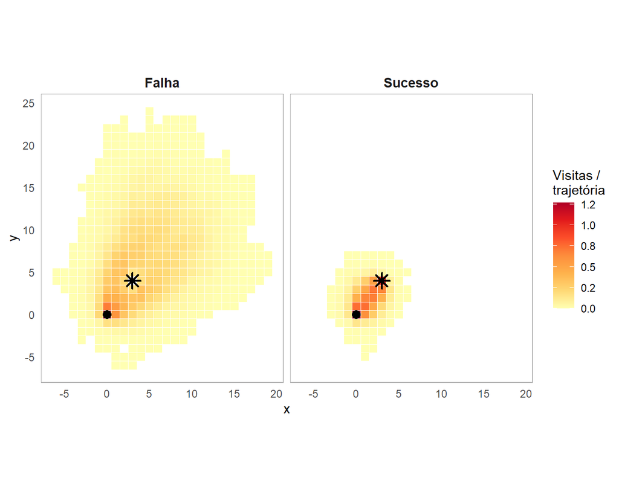

Figura 11: Mapa de calor das posições visitadas em 1.000 trajetórias de sucesso (direita) e 1.000 de falha (esquerda). A intensidade de cor representa a frequência de visitas normalizada pelo número de trajetórias. Origem marcada com círculo preto; destino com asterisco.

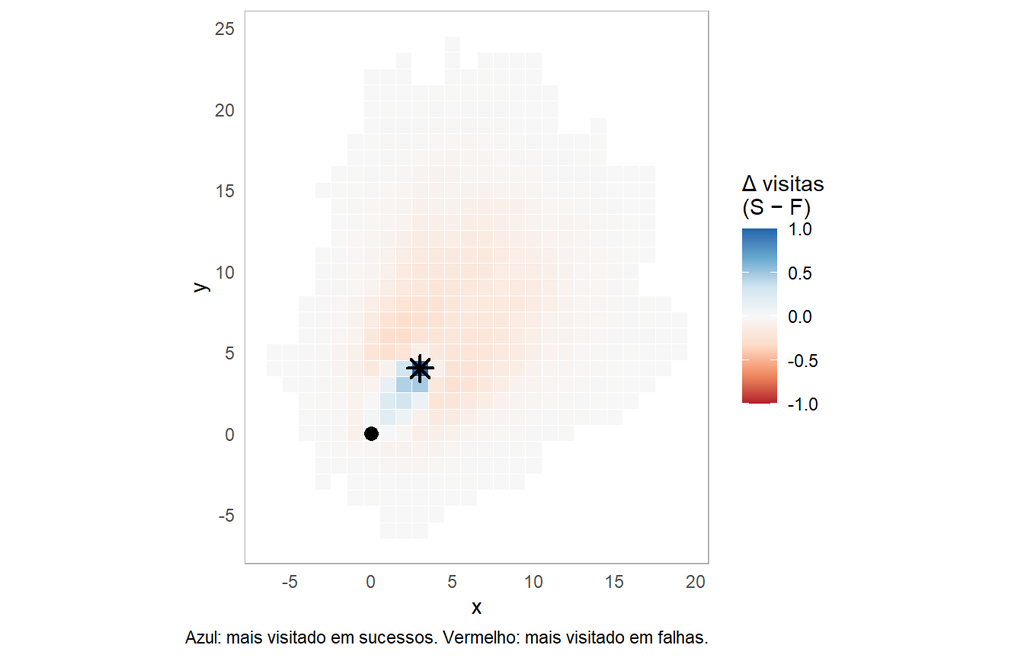

Figura 12: Diferença de frequência de visitas (Sucesso $-$ Falha) por célula da malha. Células azuis são proporcionalmente mais visitadas em trajetórias de sucesso; células vermelhas em trajetórias de falha. Células brancas têm frequência similar nos dois grupos.

## 4.3 Comparação de CDFs

A Seção 3.4 apresentou a CDF condicional — $P(T \leq t \mid \text{chegada})$ — como ferramenta analítica para a distribuição dos tempos de chegada. Esta seção produz uma visualização mais completa, reunindo em um único gráfico **duas perspectivas complementares** da função de distribuição acumulada:

1. **CDF marginal** $F(t) = P(T \leq t)$: inclui todas as $N$ simulações; as não-chegadas contribuem com $T = +\infty$, de modo que $F(t) \to \hat{p} < 1$.
2. **CDF condicional** $F(t \mid \text{chegada}) = P(T \leq t \mid T < \infty)$: restrita às tentativas bem-sucedidas; converge a $1$.

**Código**

```r
# grade comum de tempos (apenas os possíveis: ≥ 35)
t_cdf <- seq(35, max(t_cheg))

# CDF marginal: conta chegadas com tempo ≤ t* sobre TODAS as simulações
cdf_marginal   <- sapply(t_cdf, function(t) mean(chegou & tempo <= t))

# CDF condicional: ECDF calculada só nos tempos de chegada
ecdf_cond      <- ecdf(t_cheg)
cdf_condicional <- ecdf_cond(t_cdf)

# banda bootstrap para a CDF condicional (percentil 95%)
B_cdf2   <- 2000L
boot_cond <- replicate(B_cdf2, {
  ecdf(sample(t_cheg, length(t_cheg), replace = TRUE))(t_cdf)
})
cdf_cond_inf <- apply(boot_cond, 1, quantile, 0.025)
cdf_cond_sup <- apply(boot_cond, 1, quantile, 0.975)

# consolida
cdf_plot_df <- data.frame(
  t              = t_cdf,
  marginal       = cdf_marginal,
  condicional    = cdf_condicional,
  cond_inf       = cdf_cond_inf,
  cond_sup       = cdf_cond_sup
)
```

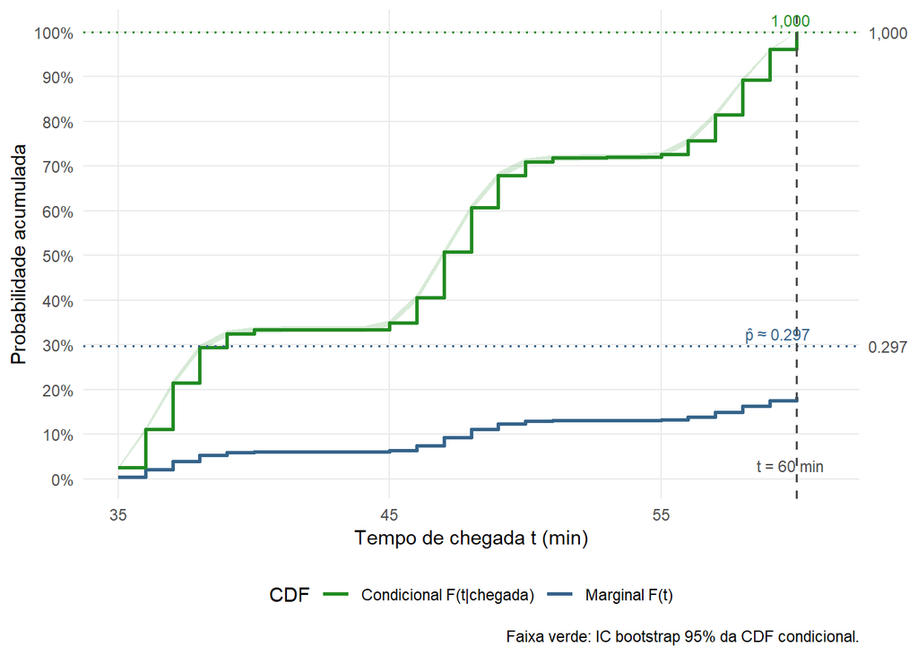

Figura 13: CDF marginal $F(t)$ (azul escuro) e CDF condicional $F(t \mid \text{chegada})$ (verde) dos tempos de chegada. A faixa verde clara é a banda de confiança bootstrap 95% da CDF condicional. As linhas tracejadas marcam $t = 60$ min (vertical) e os limites assintóticos de cada curva (horizontais). Os degraus são visíveis na região inicial — consequência direta da estrutura discreta derivada na Seção 1.2.

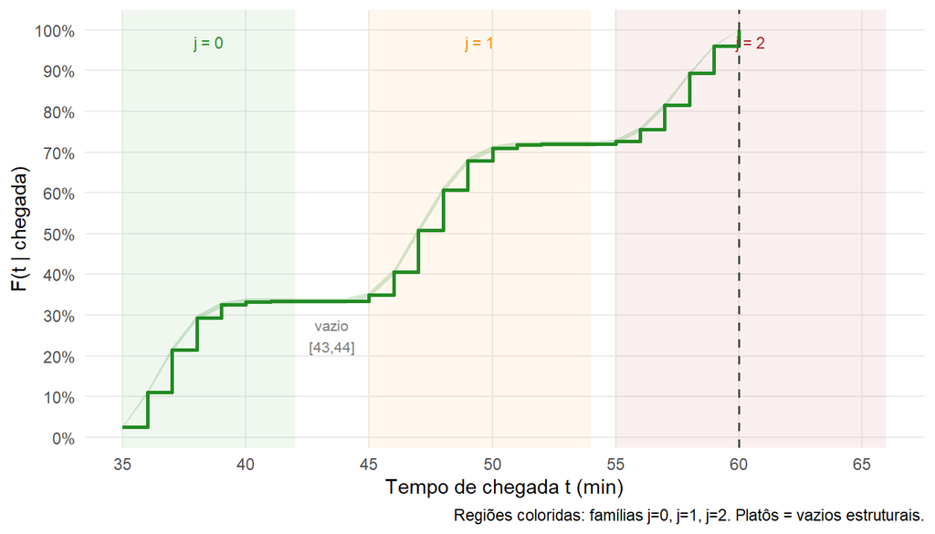

Quantis selecionados da distribuição condicional $F(t \mid \text{chegada})$.

| Quantil | t (min) | Interpretação |
| --- | --- | --- |
| 10% | 36 | 10% dos sucessos chegam até este tempo |
| 25% | 38 | 25% dos sucessos chegam até este tempo (Q1) |
| 50% | 47 | Metade dos sucessos chega até aqui (mediana) |
| 75% | 56 | 75% dos sucessos chegam até este tempo (Q3) |
| 90% | 59 | 90% dos sucessos chegam até este tempo |
| 95% | 59 | 95% dos sucessos chegam até este tempo |
| 99% | 60 | 99% dos sucessos chegam até este tempo |

# 5 Discussão e Conclusões

## 5.1 Interpretação dos Resultados

### 5.1.1 Item 1 — Probabilidade de chegada em até 60 minutos

Síntese dos resultados do Item 1: probabilidade de chegada em até 60 minutos.

| Componente | Resultado |
| --- | --- |
| Probabilidade estimada ($\hat{p}$) | 0.18240 |
| IC Wilson 95% | [0.18002, 0.18481] |
| IC Bootstrap 95% | [0.17999, 0.18476] |

O bêbado chega em casa em até $60$ minutos em aproximadamente $\hat{p}$ das tentativas. Wilson e Bootstrap produzem intervalos praticamente idênticos — esperado para $N = 100.000$, onde ambos convergem para a mesma cobertura assintótica. O valor parece modesto porque o limite de $60$ min corresponde a apenas $12$ quadras sem atrasos, com $20\%$ de chance de desvio a cada passo.

### 5.1.2 Item 2 — Distribuição em 100 tentativas

A distribuição simulada do número de chegadas em grupos de $100$ tentativas aderiu à $\text{Binomial}(100, \hat{p})$ — confirmado pelo teste qui-quadrado. Esse resultado decorre diretamente da independência entre tentativas garantida pela estrutura da simulação: cada tentativa reinicia do zero, sem memória das anteriores.

### 5.1.3 Item 3 — Distribuição dos tempos de chegada

A distribuição dos tempos revela a estrutura discreta derivada analiticamente na Seção 1.2: tempos de chegada formam famílias separadas por vazios estruturais nos primeiros $70$ minutos, com picos multimodais que a simulação confirma.

A distribuição **condicional** ($T \leq 60$ min) apresenta média e mediana aproximadamente iguais — consequência do truncamento que elimina a cauda direita. A mediana é a medida de tendência central mais robusta para descrever o tempo típico de chegada.

### 5.1.4 Item 4 — Curva probabilidade $\times$ tempo-limite

A curva $p(t^*)$ exibe três fases bem definidas nos dados simulados:

- **Degraus ($35 \leq t^* \lesssim 65$ min):** as famílias $j = 0$, $j = 1$ e $j = 2$ contribuem com saltos de probabilidade separados pelos vazios estruturais da Seção 1.2.
- **Crescimento suave ($65 \lesssim t^* \lesssim 120$ min):** as famílias $j \geq 3$ adicionam probabilidade de forma decrescente; a curva começa a se aplainar à medida que caminhos mais longos tornam-se exponencialmente menos prováveis.
- **Convergência assintótica ($t^* \gtrsim 120$ min):** a curva aproxima-se de $p(\infty) < 1$ sem jamais atingi-lo exatamente. O limite ser estritamente menor que $1$ é uma propriedade fundamental do passeio aleatório assimétrico: existe probabilidade positiva — embora ínfima — de o bêbado jamais alcançar $(3, 4)$.

O formato suavemente assintótico da curva além de $t^* = 60$ min — visível apenas graças ao horizonte de simulação de $180$ min — é o resultado correto que a teoria prediz. Uma simulação com horizonte curto (ex.: $60$ min) interrompe artificialmente toda trajetória antes da chegada, colapsando a curva num degrau falso e gerando a conclusão errônea de que o limite assintótico seria atingido em $\approx 70$ min.

## 5.2 Limitações do Modelo

O modelo adotado impõe simplificações que merecem consideração:

**Malha infinita e sem obstáculos.** A cidade real tem limites, ruas de mão única, bloqueios e atalhos. O modelo assume que o bêbado pode andar indefinidamente em qualquer direção sem restrição, o que superestima a probabilidade de trajetórias muito longas.

**Probabilidades fixas e independentes da posição.** No modelo, a probabilidade de escolher norte é sempre $0{,}45$ — mesmo quando o bêbado está ao norte do destino e deveria preferencialmente ir para sul. Um modelo mais realista poderia fazer as probabilidades depender da posição relativa ao destino, tornando o processo uma cadeia de Markov não-homogênea.

**Tempo de decisão binário.** O atraso de $1$ minuto ocorre com probabilidade $0{,}30$ ou não ocorre — sem gradação. Uma generalização natural seria modelar o tempo de decisão como uma variável aleatória contínua (ex.: $\text{Exponencial}(\lambda)$), o que tornaria a distribuição de $T$ mais suave e eliminaria parte dos picos discretos.

**Ausência de cansaço ou efeito de memória.** O modelo supõe que a $k$-ésima quadra é percorrida ao mesmo ritmo que a primeira. Na prática, o cansaço poderia aumentar o tempo por quadra ou a probabilidade de atraso nas decisões ao longo da tentativa.

## 5.3 Considerações Finais

A simulação de Monte Carlo mostrou-se um instrumento poderoso para analisar sistemas estocásticos cuja complexidade combinatória inviabiliza a solução analítica exata. Os $N = 100.000$ cenários simulados produziram estimativas precisas — erro padrão $\text{EP} < 0{,}002$ para $\hat{p}$ — e permitiram responder a todas as perguntas do enunciado a partir de um único conjunto de dados reutilizado em múltiplas análises.

A abordagem destacou-se por integrar teoria e simulação: a análise combinatória da Seção 1.2 gerou previsões — vazios estruturais, $t_{\min} = 35$ min, limite assintótico $< 1$ — sistematicamente verificadas pelos resultados computacionais.